# Bölüm 30 Ek Uygulama: Fashion-MNIST ile Kötü Amaçlı Örnekler

**Kaynak:** Christoph Molnar, *Interpretable Machine Learning*, 3. baskı, Bölüm 30 **Hazırlayan:** Talha Karaca

Bu notebook, bölümdeki saldırı yöntemlerini **Fashion-MNIST** veri seti üzerinde uygular. Veri setinde 28×28 piksellik gri tonlamalı giysi görüntüleri ve 10 kategori bulunur:

> Tişört, Pantolon, Kazak, Elbise, Mont, Sandalet, Gömlek, Spor ayakkabı, Çanta, Bot

Kategorilerin bir kısmı birbirine çok benzer (tişört, gömlek, kazak ve mont; sandalet, spor ayakkabı ve bot). Bu benzerlik, saldırıların modeli hangi yöne ittiğini incelemeyi kolaylaştırır. Veri ilk çalıştırmada yaklaşık 30 MB olarak indirilir ve `veri/` klasörüne kaydedilir. GPU gerekmez.

| # | Bölüm | Kitaptaki karşılığı |
| --- | --- | --- |
| 0 | Veri ve model | – |
| 1 | Hızlı gradyan işaret yöntemi (FGSM) | Rahatsız Edilmiş Panda |
| 2 | Saldırı hangi kategoriyi hangisine dönüştürüyor? | – |
| 3 | Hedefli saldırı: kutu kısıtlamalı L-BFGS | Köpeğimde Bir Terslik Var |
| 4 | 1-piksel saldırısı (diferansiyel evrim) | Bir Denizanası… Hayır, Bekle. Bir Küvet |
| 5 | Kara kutu saldırısı (vekil model) | Gözü Bağlı Düşman |
| 6 | Savunma: adversarial eğitim | Siber Güvenlik Perspektifi |

Tüm grafikler ayrıca `gorseller/` klasörüne PNG olarak kaydedilir.

```python
import gzip
import urllib.request
from pathlib import Path

import numpy as np
import matplotlib.pyplot as plt
import torch
import torch.nn as nn
import torch.nn.functional as F
from matplotlib.patches import Rectangle
from scipy.optimize import minimize, differential_evolution
from sklearn.ensemble import RandomForestClassifier

SEED = 42
np.random.seed(SEED)
torch.manual_seed(SEED)

GORSEL = Path("gorseller"); GORSEL.mkdir(exist_ok=True)
VERI = Path("veri"); VERI.mkdir(exist_ok=True)
plt.rcParams.update({"figure.dpi": 110, "font.size": 10, "axes.titlesize": 10})

SINIFLAR = ["Tişört", "Pantolon", "Kazak", "Elbise", "Mont",
            "Sandalet", "Gömlek", "Spor ayakkabı", "Çanta", "Bot"]

def kaydet(fig, ad):
    fig.savefig(GORSEL / f"{ad}.png", bbox_inches="tight", dpi=150)

def goster(ax, img, baslik="", cmap="gray", **kw):
    ax.imshow(np.asarray(img).reshape(28, 28), cmap=cmap, **kw)
    ax.set_title(baslik)
    ax.set_xticks([]); ax.set_yticks([])
```

## 0. Veri ve model

Fashion-MNIST dosyalarını indirip okuyoruz. Piksel değerlerini 255'e bölerek **[0, 1]** aralığına getiriyoruz. Hızlı çalışması için 60.000 eğitim görüntüsünün 20.000'ini kullanıyoruz.

10.000 görüntülük test kümesini ikiye ayırıyoruz:

- **değerlendirme kümesi** (2.000 görüntü): saldırıların başarısını ölçmek için,
- **saldırgan havuzu** (kalan görüntüler): kara kutu saldırısında saldırganın elindeki, eğitim verisinden bağımsız görüntüler (Bölüm 5).

```
Eğitim: 20000  ·  Değerlendirme: 2000  ·  Saldırgan havuzu: 8000
```

[figure not shown]

```python
URL = "http://fashion-mnist.s3-website.eu-central-1.amazonaws.com/"

def indir_oku(ad, goruntu):
    yol = VERI / f"{ad}.gz"
    if not yol.exists():
        urllib.request.urlretrieve(URL + f"{ad}.gz", yol)
    with gzip.open(yol, "rb") as f:
        veri = np.frombuffer(f.read(), np.uint8, offset=16 if goruntu else 8)
    return veri.reshape(-1, 28, 28) if goruntu else veri

X_tum = indir_oku("train-images-idx3-ubyte", True).astype(np.float32) / 255
y_tum = indir_oku("train-labels-idx1-ubyte", False).astype(np.int64)
X_t = indir_oku("t10k-images-idx3-ubyte", True).astype(np.float32) / 255
y_t = indir_oku("t10k-labels-idx1-ubyte", False).astype(np.int64)

rng = np.random.default_rng(SEED)
secim = rng.permutation(len(X_tum))[:20000]
X_egitim, y_egitim = X_tum[secim], y_tum[secim]
karisik = rng.permutation(len(X_t))
X_test, y_test = X_t[karisik[:2000]], y_t[karisik[:2000]]
X_saldirgan, y_saldirgan = X_t[karisik[2000:]], y_t[karisik[2000:]]
print(f"Eğitim: {len(X_egitim)}  ·  Değerlendirme: {len(X_test)}  ·  Saldırgan havuzu: {len(X_saldirgan)}")

fig, axes = plt.subplots(2, 10, figsize=(13, 3.2))
for k in range(10):
    for satir, i in enumerate(np.where(y_egitim == k)[0][:2]):
        goster(axes[satir, k], X_egitim[i], SINIFLAR[k] if satir == 0 else "")
fig.suptitle("Fashion-MNIST: her kategoriden iki örnek (28×28 piksel)", y=1.02)
kaydet(fig, "00_veri_ornekleri"); plt.show()
```

Saldırıların hedefi küçük bir **evrişimli sinir ağıdır (CNN)**: iki evrişim katmanı ve iki tam bağlantılı katman.

```
Değerlendirme kümesinde doğruluk: 0.892
```

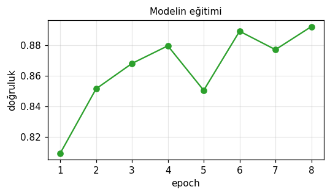

```python
class CNN(nn.Module):
    def __init__(self):
        super().__init__()
        self.c1 = nn.Conv2d(1, 32, 3, padding=1)
        self.c2 = nn.Conv2d(32, 64, 3, padding=1)
        self.fc1 = nn.Linear(64 * 7 * 7, 128)
        self.fc2 = nn.Linear(128, 10)

    def forward(self, x):
        x = x.reshape(-1, 1, 28, 28)
        x = F.max_pool2d(F.relu(self.c1(x)), 2)
        x = F.max_pool2d(F.relu(self.c2(x)), 2)
        x = F.relu(self.fc1(x.flatten(1)))
        return self.fc2(x)

T = lambda a: torch.tensor(a, dtype=torch.float32)
Xtr, ytr = T(X_egitim), torch.tensor(y_egitim)
Xte, yte = T(X_test), torch.tensor(y_test)

@torch.no_grad()
def dogruluk(model, X, y, bs=1000):
    model.eval()
    dogru = sum((model(X[i:i + bs]).argmax(1) == y[i:i + bs]).sum().item() for i in range(0, len(X), bs))
    return dogru / len(X)

@torch.no_grad()
def tahmin(model, x):
    model.eval()
    p = F.softmax(model(x.reshape(1, 28, 28)), dim=1)[0]
    return int(p.argmax()), float(p.max())

def egit(model, X, y, epoch=8, bs=128, lr=1e-3, adv_eps=None):
    # adv_eps verilirse her mini-yığına FGSM örnekleri eklenir (adversarial eğitim, Bölüm 6).
    opt = torch.optim.Adam(model.parameters(), lr=lr)
    gecmis = []
    for _ in range(epoch):
        model.train()
        perm = torch.randperm(len(X))
        for i in range(0, len(X), bs):
            idx = perm[i:i + bs]
            xb, yb = X[idx], y[idx]
            if adv_eps is not None:
                xb = torch.cat([xb, fgsm(model, xb, yb, adv_eps)])
                yb = torch.cat([yb, yb])
            opt.zero_grad()
            F.cross_entropy(model(xb), yb).backward()
            opt.step()
        gecmis.append(dogruluk(model, Xte, yte))
    return gecmis

model = CNN()
gecmis = egit(model, Xtr, ytr)
print(f"Değerlendirme kümesinde doğruluk: {dogruluk(model, Xte, yte):.3f}")

fig, ax = plt.subplots(figsize=(5, 3))
ax.plot(range(1, len(gecmis) + 1), gecmis, "o-", color="tab:green")
ax.set_xlabel("epoch"); ax.set_ylabel("doğruluk"); ax.set_title("Modelin eğitimi"); ax.grid(alpha=0.3)
fig.tight_layout(); kaydet(fig, "01_egitim"); plt.show()
```

Model temiz görüntülerde yaklaşık %90 doğruluğa ulaşır. Bu, Fashion-MNIST için küçük bir CNN'den beklenen düzeydir.

## 1. Hızlı gradyan işaret yöntemi (FGSM)

Goodfellow vd. (2015), görüntünün her pikseline kaybı artıran yönde küçük bir $\epsilon$ ekler veya çıkarır:

$$\mathbf{x}^\prime = \mathbf{x} + \epsilon \cdot \text{sign}\left(\nabla_{\mathbf{x}} J(\boldsymbol{\theta}, \mathbf{x}, y)\right)$$

Gradyanın yalnızca işareti kullanılır: Bir pikselin parlaklığını artırmak kaybı artırıyorsa +1, azaltmak kaybı artırıyorsa −1. Tek bir gradyan hesabı yeterlidir.

Aşağıda ε = 0,05 kullanıyoruz; her piksel en fazla 255 üzerinden yaklaşık 13 birim değişir.

[figure not shown]

```python
def fgsm(model, x, y, eps):
    x = x.clone().detach().requires_grad_(True)
    grad, = torch.autograd.grad(F.cross_entropy(model(x), y), x)
    return (x + eps * grad.sign()).clamp(0, 1).detach()

with torch.no_grad():
    dogru = (model(Xte).argmax(1) == yte).nonzero().flatten()

EPS = 0.05
secilen = torch.stack([dogru[(yte[dogru] == k).nonzero()[0, 0]] for k in (0, 1, 3, 5, 7, 8, 9)])
x_adv = fgsm(model, Xte[secilen], yte[secilen], EPS)

fig, axes = plt.subplots(3, len(secilen), figsize=(13, 6.2))
for j, i in enumerate(secilen):
    s0, p0 = tahmin(model, Xte[i]); s1, p1 = tahmin(model, x_adv[j])
    goster(axes[0, j], Xte[i], f"{SINIFLAR[s0]} (%{100*p0:.0f})")
    goster(axes[1, j], (x_adv[j] - Xte[i]), "", cmap="bwr", vmin=-EPS, vmax=EPS)
    goster(axes[2, j], x_adv[j], f"{SINIFLAR[s1]} (%{100*p1:.0f})")
    axes[2, j].title.set_color("red" if s1 != s0 else "black")
for ax, etiket in zip(axes[:, 0], ["orijinal x", "eklenen değişiklik", f"x′  (ε={EPS})"]):
    ax.set_ylabel(etiket, fontsize=11)
fig.suptitle("FGSM: değişiklik gözle zor seçilir, model tahminini değiştirir", y=1.0)
fig.tight_layout(); fig.subplots_adjust(hspace=0.3); kaydet(fig, "02_fgsm_ornekler"); plt.show()
```

Üst ve alt satırdaki görüntüler insan gözüne neredeyse aynı görünür. Kırmızı başlıklar modelin yanıldığı görüntülerdir; model çoğu zaman yanlış kategoriyi yüksek güvenle tahmin eder.

FGSM'in etkisini aynı büyüklükteki **rastgele gürültüyle** karşılaştırıyoruz. Rastgele gürültüde her piksele yine ±ε eklenir, işaretler rastgele seçilir.

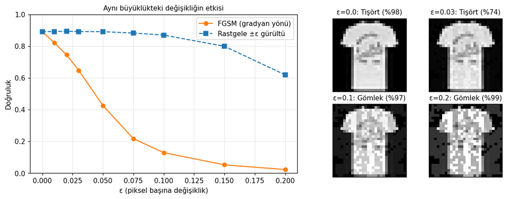

```
ε=0.02:  FGSM sonrası doğruluk 0.75  ·  rastgele gürültü sonrası 0.89
ε=0.05:  FGSM sonrası doğruluk 0.43  ·  rastgele gürültü sonrası 0.89
ε=0.1:  FGSM sonrası doğruluk 0.13  ·  rastgele gürültü sonrası 0.87
```

```python
eps_listesi = [0, 0.01, 0.02, 0.03, 0.05, 0.075, 0.1, 0.15, 0.2]
torch.manual_seed(SEED)
acc_fgsm = [dogruluk(model, fgsm(model, Xte, yte, e), yte) for e in eps_listesi]
acc_gurultu = [dogruluk(model, (Xte + e * torch.randn_like(Xte).sign()).clamp(0, 1), yte) for e in eps_listesi]

fig = plt.figure(figsize=(11, 4.2))
ax = fig.add_axes([0.06, 0.12, 0.5, 0.78])
ax.plot(eps_listesi, acc_fgsm, "o-", color="tab:orange", label="FGSM (gradyan yönü)")
ax.plot(eps_listesi, acc_gurultu, "s--", color="tab:blue", label="Rastgele ±ε gürültü")
ax.set_xlabel("ε (piksel başına değişiklik)"); ax.set_ylabel("Doğruluk")
ax.set_ylim(0, 1.0); ax.grid(alpha=0.3); ax.legend()
ax.set_title("Aynı büyüklükteki değişikliğin etkisi")
i0 = int(secilen[0])
for k, e in enumerate([0.0, 0.03, 0.1, 0.2]):
    a = fig.add_axes([0.62 + (k % 2) * 0.18, 0.52 - (k // 2) * 0.42, 0.15, 0.36])
    xa = fgsm(model, Xte[i0][None], yte[i0][None], e)[0]
    s, p = tahmin(model, xa)
    goster(a, xa, f"ε={e}: {SINIFLAR[s]} (%{100*p:.0f})")
kaydet(fig, "03_fgsm_eps_egrisi"); plt.show()

for e, a1, a2 in zip(eps_listesi, acc_fgsm, acc_gurultu):
    if e in (0.02, 0.05, 0.1):
        print(f"ε={e}:  FGSM sonrası doğruluk {a1:.2f}  ·  rastgele gürültü sonrası {a2:.2f}")
```

Rastgele gürültü doğruluğu çok az değiştirir. FGSM, gözle zor fark edilen ε = 0,02–0,05 düzeyinde bile doğruluğu hızla düşürür. Saldırının gücü, değişikliğin yönünün modelin gradyanına göre seçilmesinden gelir. Bölümde anlatıldığı gibi, ağ piksel yoğunluğu ile sınıf skoru arasındaki ilişkiyi yerel olarak doğrusala yakın ele alır; tüm pikseller gradyan yönünde birlikte itildiğinde skorlar büyük ölçüde değişir.

## 2. Saldırı hangi kategoriyi hangisine dönüştürüyor?

Çok kategorili bir veri setinde şu soru sorulabilir: FGSM bir görüntüyü yanlış sınıfa ittiğinde hangi sınıfa iter? Aşağıdaki matris, ε = 0,05 saldırısından sonra her gerçek kategorinin hangi kategoriler olarak tahmin edildiğini gösterir (satırlar yüzde olarak normalize edilmiştir).

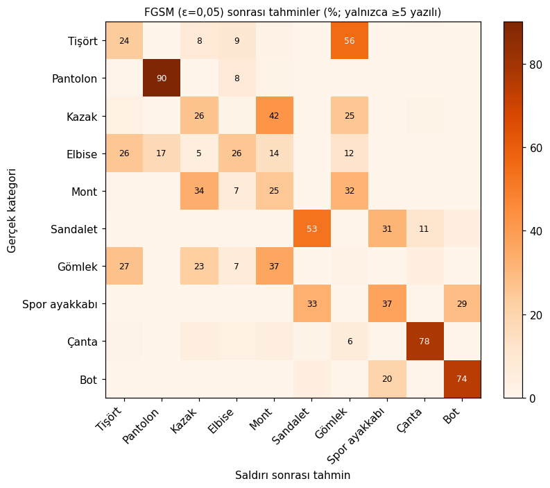

```
Tişört         → en sık Gömlek         (%56)
Pantolon       → en sık Elbise         (%8)
Kazak          → en sık Mont           (%42)
Elbise         → en sık Tişört         (%26)
Mont           → en sık Kazak          (%34)
Sandalet       → en sık Spor ayakkabı  (%31)
Gömlek         → en sık Mont           (%37)
Spor ayakkabı  → en sık Sandalet       (%33)
Çanta          → en sık Gömlek         (%6)
Bot            → en sık Spor ayakkabı  (%20)
```

```python
x_adv_tum = fgsm(model, Xte, yte, 0.05)
with torch.no_grad():
    tahmin_adv = model(x_adv_tum).argmax(1).numpy()
matris = np.zeros((10, 10))
for g, t in zip(y_test, tahmin_adv):
    matris[g, t] += 1
matris = matris / matris.sum(1, keepdims=True) * 100

fig, ax = plt.subplots(figsize=(7.5, 6.5))
im = ax.imshow(matris, cmap="Oranges")
for g in range(10):
    for t in range(10):
        if matris[g, t] >= 5:
            ax.text(t, g, f"{matris[g, t]:.0f}", ha="center", va="center",
                    color="white" if matris[g, t] > 50 else "black", fontsize=8)
ax.set_xticks(range(10)); ax.set_xticklabels(SINIFLAR, rotation=45, ha="right")
ax.set_yticks(range(10)); ax.set_yticklabels(SINIFLAR)
ax.set_xlabel("Saldırı sonrası tahmin"); ax.set_ylabel("Gerçek kategori")
ax.set_title("FGSM (ε=0,05) sonrası tahminler (%; yalnızca ≥5 yazılı)")
fig.colorbar(im, ax=ax, fraction=0.046)
fig.tight_layout(); kaydet(fig, "04_karisiklik_matrisi"); plt.show()

hedefler = matris.copy(); np.fill_diagonal(hedefler, 0)
for g in range(10):
    t = int(hedefler[g].argmax())
    print(f"{SINIFLAR[g]:<14} → en sık {SINIFLAR[t]:<14} (%{hedefler[g, t]:.0f})")
```

Görüntüler çoğunlukla **görsel olarak benzer** kategorilere kayar: Üst giyim kategorileri (tişört, gömlek, kazak, mont) kendi aralarında, ayakkabı kategorileri (sandalet, spor ayakkabı, bot) kendi aralarında yer değiştirir. Gradyan görüntüyü en yakın karar sınırına doğru iter; bu sınır genellikle benzer bir kategoriyle ortak sınırdır.

Pantolon, çanta ve bot daha dayanıklıdır: Saldırıdan sonra bu görüntülerin %74–90'ı doğru sınıflandırılmaya devam eder. Bu kategorilerin şekli diğerlerinden belirgin biçimde ayrıldığı için karar sınırına uzaklıkları daha fazladır.

## 3. Hedefli saldırı: kutu kısıtlamalı L-BFGS

Szegedy vd. (2014), modeli **seçilen bir hedef kategoriye** ($l$) yönlendiren küçük bir değişiklik arar:

$$\text{loss}(\hat{f}(\mathbf{x}+\mathbf{r}), l) + c \cdot |\mathbf{r}|$$

Piksel değerleri [0, 1] aralığında tutulur; problem kutu kısıtlamalı L-BFGS (`scipy`'de `L-BFGS-B`) ile çözülür. $|\mathbf{r}|$ için türevlenebilir olması amacıyla Öklid normunun karesini kullanıyoruz. $c$ büyüdükçe değişiklik küçülür; $c$'yi büyükten küçüğe deneyip saldırının başarılı olduğu ilk değeri seçiyoruz.

Kitaptaki "hepsi devekuşu" örneğine benzer bir deney yapıyoruz: Her kategoriden bir görüntüyü **"Çanta"** olarak sınıflandırtıyoruz.

[figure not shown]

```python
def lbfgs_saldirisi(model, x, hedef, c_listesi=(3.0, 1.0, 0.3, 0.1, 0.03, 0.01, 0.003)):
    model.eval()
    x0 = x.flatten().numpy().astype(np.float64)
    x0_t = torch.tensor(x0, dtype=torch.float32)
    hedef_t = torch.tensor([hedef])
    for c in c_listesi:
        def amac(xp):
            xp_t = torch.tensor(xp, dtype=torch.float32, requires_grad=True)
            toplam = F.cross_entropy(model(xp_t), hedef_t) + c * ((xp_t - x0_t) ** 2).sum()
            g, = torch.autograd.grad(toplam, xp_t)
            return toplam.item(), g.numpy().astype(np.float64)
        sonuc = minimize(amac, x0, jac=True, method="L-BFGS-B", bounds=[(0, 1)] * 784)
        x_yeni = torch.tensor(sonuc.x, dtype=torch.float32).reshape(28, 28)
        if tahmin(model, x_yeni)[0] == hedef:
            return x_yeni, c
    return x_yeni, None

HEDEF = 8   # Çanta
kaynaklar = [int(dogru[(yte[dogru] == k).nonzero()[0, 0]]) for k in range(10) if k != HEDEF]

fig, axes = plt.subplots(3, 9, figsize=(14, 5.6))
for j, i in enumerate(kaynaklar):
    x_h, c = lbfgs_saldirisi(model, Xte[i], HEDEF)
    r = x_h - Xte[i]
    s1, p1 = tahmin(model, x_h)
    goster(axes[0, j], Xte[i], SINIFLAR[int(yte[i])])
    m = float(r.abs().max()) or 1.0
    goster(axes[1, j], r, f"|r|={float(r.norm()):.2f}", cmap="bwr", vmin=-m, vmax=m)
    goster(axes[2, j], x_h, f"{SINIFLAR[s1]} (%{100*p1:.0f})")
    axes[2, j].title.set_color("red" if s1 == HEDEF else "black")
for ax, etiket in zip(axes[:, 0], ["orijinal", "r (büyütülmüş)", "x + r"]):
    ax.set_ylabel(etiket, fontsize=11)
fig.suptitle("Hedefli L-BFGS saldırısı: her giysi \"Çanta\" olarak sınıflandırılıyor", y=1.0)
fig.tight_layout(); fig.subplots_adjust(hspace=0.3); kaydet(fig, "05_lbfgs_hedefli"); plt.show()
```

Orta satır eklenen değişikliği kendi ölçeğinde büyütülmüş olarak gösterir. Alt satırdaki görüntüler orijinallerine çok benzer ve model hepsini "Çanta" olarak sınıflandırır. Bu formülasyon karşıt açıklamalarda kullanılan kayıp fonksiyonuyla neredeyse aynıdır; buradaki amaç modeli kandırmaktır.

## 4. 1-piksel saldırısı (diferansiyel evrim)

Su vd. (2019), modeli **tek bir pikseli** değiştirerek kandırmayı dener. Saldırı gradyan kullanmaz; yalnızca modelin tahmin olasılıklarına bakar.

Her aday çözüm bir piksel değişikliğidir. Gri tonlamalı görüntülerde aday 3 elemanlıdır: (satır, sütun, yeni değer). Yeni adaylar diferansiyel evrimle üretilir:

$$\mathbf{x}_{g+1}^{(i)} = \mathbf{x}_g^{(r1)} + F \cdot (\mathbf{x}_g^{(r2)}- \mathbf{x}_g^{(r3)})$$

Kitaptaki gibi $F = 0{,}5$ ve yaklaşık 400 aday kullanıyoruz. Amaç gerçek kategorinin olasılığını en aza indirmektir. Model yanlış kategoriyi tahmin ettiğinde arama durur.

```python
@torch.no_grad()
def tek_piksel_saldirisi(model, x, y_gercek, maxiter=50, seed=SEED):
    model.eval()

    def uygula(adaylar):                        # adaylar: (3, N)
        N = adaylar.shape[1]
        xs = x.repeat(N, 1, 1)
        r = np.clip(adaylar[0].astype(int), 0, 27)
        s = np.clip(adaylar[1].astype(int), 0, 27)
        xs[torch.arange(N), r, s] = torch.tensor(adaylar[2], dtype=torch.float32)
        return xs

    def amac(adaylar):
        adaylar = adaylar.reshape(3, -1)
        return F.softmax(model(uygula(adaylar)), dim=1)[:, y_gercek].numpy()

    def dur(intermediate_result):
        return int(model(uygula(intermediate_result.x.reshape(3, 1))).argmax(1)) != y_gercek

    sonuc = differential_evolution(
        amac, bounds=[(0, 27.999), (0, 27.999), (0, 1)], popsize=133,   # 133 × 3 ≈ 400 aday
        mutation=0.5, recombination=1.0, maxiter=maxiter, seed=seed,
        vectorized=True, updating="deferred", polish=False, callback=dur)
    return uygula(sonuc.x.reshape(3, 1))[0], (int(sonuc.x[0]), int(sonuc.x[1]))

N_DENEME = 100
basarili = []
for i in dogru[:N_DENEME]:
    x_yeni, konum = tek_piksel_saldirisi(model, Xte[i], int(yte[i]))
    s1, p1 = tahmin(model, x_yeni)
    if s1 != int(yte[i]):
        basarili.append((int(i), x_yeni, konum, s1, p1))
print(f"1-piksel saldırısı başarı oranı: {len(basarili)}/{N_DENEME} = %{100*len(basarili)/N_DENEME:.0f}")
```

```
1-piksel saldırısı başarı oranı: 18/100 = %18
```

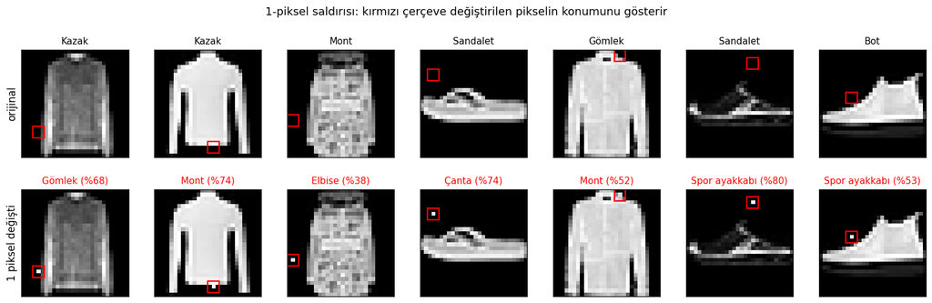

```python
gosterilecek = basarili[:7]
if gosterilecek:
    fig, axes = plt.subplots(2, len(gosterilecek), figsize=(1.9 * len(gosterilecek) + 1, 4.4), squeeze=False)
    for j, (i, x_yeni, (r, s), s1, p1) in enumerate(gosterilecek):
        goster(axes[0, j], Xte[i], SINIFLAR[int(yte[i])])
        goster(axes[1, j], x_yeni, f"{SINIFLAR[s1]} (%{100*p1:.0f})")
        axes[1, j].title.set_color("red")
        for ax in axes[:, j]:
            ax.add_patch(Rectangle((s - 1.5, r - 1.5), 3, 3, fill=False, ec="red", lw=1.5))
    axes[0, 0].set_ylabel("orijinal", fontsize=11)
    axes[1, 0].set_ylabel("1 piksel değişti", fontsize=11)
    fig.suptitle("1-piksel saldırısı: kırmızı çerçeve değiştirilen pikselin konumunu gösterir", y=1.02)
    fig.tight_layout(); fig.subplots_adjust(hspace=0.3); kaydet(fig, "06_tek_piksel"); plt.show()
```

28×28 görüntüde tek piksel, görüntünün 1/784'üdür. Saldırı bu kadar küçük bir değişiklikle görüntülerin bir kısmında başarılı olur. Başarılı örneklerin çoğunda görüntü benzer bir kategoriye kayar (kazak → gömlek, bot → spor ayakkabı). Saldırı yalnızca tahmin olasılıklarını kullandığı için **modelden bağımsızdır**.

## 5. Kara kutu saldırısı (vekil model)

Bu bölümde hedef model bir **rastgele ormandır**. Rastgele ormanın gradyanı yoktur. Saldırgan modele yalnızca görüntü gönderip **etiket** alabilir; model parametrelerine ve eğitim verisine erişemez.

Papernot vd. (2017)'nin adımları:

1. Aynı alandan birkaç görüntüyle başla (saldırgan havuzundan).
2. Bu görüntüler için kara kutudan etiket al.
3. Bu etiketlerle bir vekil model (küçük bir sinir ağı) eğit.
4. Vekilin gradyanıyla yeni sentetik görüntüler üret (Jacobian tabanlı veri artırma) ve kümeye ekle.
5. 2–4. adımları birkaç tur tekrarla.
6. Vekil model üzerinde FGSM ile adversarial örnekler üret.
7. Bu örneklerle kara kutuya saldır.

```python
kara_kutu = RandomForestClassifier(n_estimators=100, n_jobs=-1, random_state=SEED)
kara_kutu.fit(X_egitim.reshape(len(X_egitim), -1), y_egitim)
SORGU = {"sayi": 0}

def kara_kutuya_sor(x):
    # Saldırganın tek erişimi: görüntü gönder, etiket al.
    SORGU["sayi"] += len(x)
    return torch.tensor(kara_kutu.predict(x.reshape(len(x), -1).numpy()))

KK_TEST = kara_kutu.predict(X_test.reshape(len(X_test), -1))   # yalnızca değerlendirme için
print(f"Kara kutunun (rastgele orman) doğruluğu: {(KK_TEST == y_test).mean():.3f}")

class Vekil(nn.Module):
    def __init__(self):
        super().__init__()
        self.ag = nn.Sequential(nn.Linear(784, 256), nn.ReLU(), nn.Linear(256, 10))
    def forward(self, x):
        return self.ag(x.reshape(-1, 784))

def jacobian_artirma(vekil, X, etiket, lam=0.1):
    X = X.clone().requires_grad_(True)
    g, = torch.autograd.grad(vekil(X).gather(1, etiket.view(-1, 1)).sum(), X)
    return (X + lam * g.sign()).clamp(0, 1).detach()

def vekil_olustur(n_baslangic, turlar=4, yazdir=False):
    S = T(X_saldirgan[:n_baslangic])
    for tur in range(turlar):
        etiket = kara_kutuya_sor(S)
        torch.manual_seed(SEED)
        vekil = Vekil()
        opt = torch.optim.Adam(vekil.parameters(), lr=1e-3)
        for _ in range(200):
            vekil.train(); opt.zero_grad()
            F.cross_entropy(vekil(S), etiket).backward(); opt.step()
        vekil.eval()
        with torch.no_grad():
            u = (vekil(Xte).argmax(1).numpy() == KK_TEST).mean()
        if yazdir:
            print(f"Tur {tur}: vekilin veri kümesi {len(S):5d} görüntü · kara kutuyla uyum {u:.2f}")
        if tur < turlar - 1:
            S = torch.cat([S, jacobian_artirma(vekil, S, etiket)])
    return vekil, u

vekil, _ = vekil_olustur(500, yazdir=True)
VEKIL_SORGU = SORGU["sayi"]
print(f"Vekili eğitmek için yapılan kara kutu sorgusu: {VEKIL_SORGU}")
```

```
Kara kutunun (rastgele orman) doğruluğu: 0.864
```

```
Tur 0: vekilin veri kümesi   500 görüntü · kara kutuyla uyum 0.85
```

```
Tur 1: vekilin veri kümesi  1000 görüntü · kara kutuyla uyum 0.84
```

```
Tur 2: vekilin veri kümesi  2000 görüntü · kara kutuyla uyum 0.85
```

```
Tur 3: vekilin veri kümesi  4000 görüntü · kara kutuyla uyum 0.85
Vekili eğitmek için yapılan kara kutu sorgusu: 7500
```

Saldırganın elindeki gerçek görüntü sayısı vekilin kalitesini belirler. Aynı yöntemi farklı sayıda başlangıç görüntüsüyle tekrarlayıp vekilin kara kutuyla uyumunu ve saldırı sonrası kara kutunun doğruluğunu ölçüyoruz (ε = 0,1).

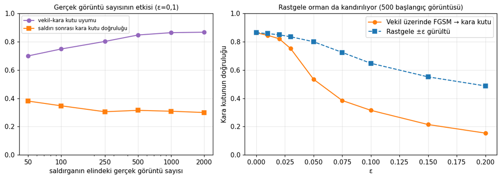

```
ε=0.05: aktarılan saldırı sonrası doğruluk 0.53 · rastgele gürültüyle 0.80
ε=0.1: aktarılan saldırı sonrası doğruluk 0.32 · rastgele gürültüyle 0.65
ε=0.2: aktarılan saldırı sonrası doğruluk 0.15 · rastgele gürültüyle 0.49
```

```python
y_kk = kara_kutuya_sor(Xte)                       # saldırgan gerçek etiketleri bilmez
dogru_kk = lambda Xa: (kara_kutu.predict(Xa.reshape(len(Xa), -1).numpy()) == y_test).mean()

n_listesi = [50, 100, 250, 500, 1000, 2000]
deney = []
for n in n_listesi:
    v, u = vekil_olustur(n)
    deney.append((u, dogru_kk(fgsm(v, Xte, y_kk, 0.1))))

torch.manual_seed(SEED)
acc_transfer = [dogru_kk(fgsm(vekil, Xte, y_kk, e)) for e in eps_listesi]
acc_kk_gurultu = [dogru_kk((Xte + e * torch.randn_like(Xte).sign()).clamp(0, 1)) for e in eps_listesi]

fig, ax = plt.subplots(1, 2, figsize=(11, 4), gridspec_kw={"width_ratios": [1, 1.3]})
ax[0].plot(n_listesi, [d[0] for d in deney], "o-", color="tab:purple", label="vekil–kara kutu uyumu")
ax[0].plot(n_listesi, [d[1] for d in deney], "s-", color="tab:orange", label="saldırı sonrası kara kutu doğruluğu")
ax[0].set_xscale("log"); ax[0].set_xticks(n_listesi); ax[0].set_xticklabels(n_listesi)
ax[0].set_xlabel("saldırganın elindeki gerçek görüntü sayısı"); ax[0].set_ylim(0, 1.0)
ax[0].set_title("Gerçek görüntü sayısının etkisi (ε=0,1)"); ax[0].grid(alpha=0.3); ax[0].legend(fontsize=8)
ax[1].plot(eps_listesi, acc_transfer, "o-", color="tab:orange", label="Vekil üzerinde FGSM → kara kutu")
ax[1].plot(eps_listesi, acc_kk_gurultu, "s--", color="tab:blue", label="Rastgele ±ε gürültü")
ax[1].set_xlabel("ε"); ax[1].set_ylabel("Kara kutunun doğruluğu"); ax[1].set_ylim(0, 1.0)
ax[1].set_title("Rastgele orman da kandırılıyor (500 başlangıç görüntüsü)"); ax[1].grid(alpha=0.3); ax[1].legend()
fig.tight_layout(); kaydet(fig, "07_kara_kutu"); plt.show()

for e, a1, a2 in zip(eps_listesi, acc_transfer, acc_kk_gurultu):
    if e in (0.05, 0.1, 0.2):
        print(f"ε={e}: aktarılan saldırı sonrası doğruluk {a1:.2f} · rastgele gürültüyle {a2:.2f}")
```

Saldırgan rastgele ormanın içini görmez ve eğitim verisine erişmez. Vekil sinir ağında bulunan adversarial örnekler kara kutuya **aktarılır** ve doğruluğunu düşürür. Saldırganın elinde ne kadar çok gerçek görüntü varsa vekil kara kutuyu o kadar iyi taklit eder ve saldırı o kadar güçlenir.

Bu sonuç bölümdeki iki tespiti destekler:

- Adversarial örnekler farklı modellere aktarılabilir.
- Yöntem, karar ağaçları gibi gradyanı olmayan modellerde de çalışır. Modeli ve veriyi gizlemek tek başına yeterli bir savunma değildir.

## 6. Savunma: adversarial eğitim

Bölümde önerilen proaktif savunma, modeli adversarial örneklerle birlikte yeniden eğitmektir. Her mini-yığına o anki modele karşı üretilmiş FGSM örneklerini (ε = 0,05) ekleyerek ikinci bir CNN eğitiyoruz.

İki modeli iki saldırıyla deniyoruz:

- **FGSM**: modelin eğitimde gördüğü saldırı,
- **PGD**: FGSM'i küçük adımlarla 10 kez uygulayan ve her adımda değişikliği ε sınırı içinde tutan, daha güçlü bir saldırı.

```
Temiz doğruluk · normal model: 0.892 · adversarial eğitimli model: 0.866
```

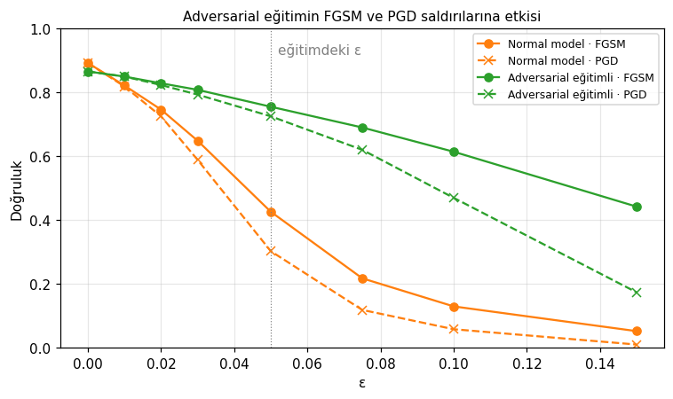

```python
def pgd(model, x, y, eps, adim=10):
    alfa = eps / 4
    x_adv = x.clone().detach()
    for _ in range(adim):
        x_adv = fgsm(model, x_adv, y, alfa)
        x_adv = torch.min(torch.max(x_adv, x - eps), x + eps).clamp(0, 1)
    return x_adv

torch.manual_seed(SEED)
saglam = CNN()
egit(saglam, Xtr, ytr, adv_eps=0.05)
print(f"Temiz doğruluk · normal model: {dogruluk(model, Xte, yte):.3f} · "
      f"adversarial eğitimli model: {dogruluk(saglam, Xte, yte):.3f}")

eps_savunma = [0, 0.01, 0.02, 0.03, 0.05, 0.075, 0.1, 0.15]
sonuclar = {}
for ad, m in [("Normal model", model), ("Adversarial eğitimli", saglam)]:
    sonuclar[ad] = {
        "FGSM": [dogruluk(m, fgsm(m, Xte, yte, e), yte) for e in eps_savunma],
        "PGD": [dogruluk(m, pgd(m, Xte, yte, e), yte) for e in eps_savunma],
    }

fig, ax = plt.subplots(figsize=(7, 4.2))
renk = {"Normal model": "tab:orange", "Adversarial eğitimli": "tab:green"}
for ad, d in sonuclar.items():
    ax.plot(eps_savunma, d["FGSM"], "o-", color=renk[ad], label=f"{ad} · FGSM")
    ax.plot(eps_savunma, d["PGD"], "x--", color=renk[ad], label=f"{ad} · PGD")
ax.axvline(0.05, color="gray", lw=0.8, ls=":"); ax.text(0.052, 0.92, "eğitimdeki ε", color="gray")
ax.set_xlabel("ε"); ax.set_ylabel("Doğruluk"); ax.set_ylim(0, 1.0); ax.grid(alpha=0.3)
ax.set_title("Adversarial eğitimin FGSM ve PGD saldırılarına etkisi")
ax.legend(fontsize=8)
fig.tight_layout(); kaydet(fig, "08_savunma"); plt.show()
```

Adversarial eğitim, modeli eğitimde gördüğü FGSM saldırısına karşı belirgin biçimde dayanıklı hâle getirir ve temiz doğruluğu çok az düşürür. Daha güçlü PGD saldırısı bu dayanıklılığın bir kısmını aşar; eğitimde kullanılan ε değerinin ötesinde koruma hızla azalır. Bölümde "kedi-fare oyunu" olarak anlatılan durum budur: Her yeni savunmaya karşı daha güçlü saldırılar geliştirilir.

## Özet

```python
i05 = eps_listesi.index(0.05); i10 = eps_listesi.index(0.1); j05 = eps_savunma.index(0.05)
satirlar = [
    ("Temiz doğruluk (CNN)", f"{dogruluk(model, Xte, yte):.2f}"),
    ("FGSM, ε=0,05 sonrası doğruluk", f"{acc_fgsm[i05]:.2f}"),
    ("Rastgele ±0,05 gürültü sonrası doğruluk", f"{acc_gurultu[i05]:.2f}"),
    ("L-BFGS hedefli saldırı (9 giysi → Çanta)", "yukarıdaki şekil"),
    ("1-piksel saldırısı başarı oranı", f"%{100*len(basarili)/N_DENEME:.0f}"),
    ("Kara kutu (rastgele orman), temiz doğruluk", f"{(KK_TEST == y_test).mean():.2f}"),
    ("Kara kutu, aktarılan FGSM ε=0,1 sonrası", f"{acc_transfer[i10]:.2f}"),
    ("Vekil için kara kutu sorgu sayısı", f"{VEKIL_SORGU}"),
    ("Adversarial eğitimli model, FGSM ε=0,05", f"{sonuclar['Adversarial eğitimli']['FGSM'][j05]:.2f}"),
    ("Adversarial eğitimli model, PGD ε=0,05", f"{sonuclar['Adversarial eğitimli']['PGD'][j05]:.2f}"),
]
genislik = max(len(s[0]) for s in satirlar)
for ad, deger in satirlar:
    print(f"{ad:<{genislik}}  {deger}")
```

```
Temiz doğruluk (CNN)                        0.89
FGSM, ε=0,05 sonrası doğruluk               0.43
Rastgele ±0,05 gürültü sonrası doğruluk     0.89
L-BFGS hedefli saldırı (9 giysi → Çanta)    yukarıdaki şekil
1-piksel saldırısı başarı oranı             %18
Kara kutu (rastgele orman), temiz doğruluk  0.86
Kara kutu, aktarılan FGSM ε=0,1 sonrası     0.32
Vekil için kara kutu sorgu sayısı           7500
Adversarial eğitimli model, FGSM ε=0,05     0.76
Adversarial eğitimli model, PGD ε=0,05      0.72
```

**Çıkarımlar**

1. Temiz verideki yüksek doğruluk modelin sağlam olduğunu göstermez.
2. Gözle zor fark edilen değişiklikler (ε = 0,02–0,05) doğruluğu büyük ölçüde düşürür. Aynı büyüklükteki rastgele gürültünün etkisi küçüktür; saldırının gücü değişikliğin yönünden gelir.
3. Saldırılar görüntüleri çoğunlukla görsel olarak benzer kategorilere iter.
4. Gradyan gerektirmeyen saldırılar (1-piksel, kara kutu) da etkilidir.
5. Adversarial eğitim modelin dayanıklılığını artırır. Daha güçlü saldırılar bu korumayı kısmen aşar.

**Kitaptaki diğer yöntemler:** Adversarial yama ve EOT (3D kaplumbağa) fiziksel dünyaya yönelik saldırılardır ve büyük görüntü modelleri gerektirir. Bu nedenle bu notebook'ta uygulanmadı.